# Data challenges (Onderwijs voor Professionals)

Missende data en multipele imputatie met `mice`

## Het probleem van missende data

Het hoorcollege van dit deel is beschikbaar via deze link.

This tutorial will give you an introduction to the `R`-package `mice`, an open-source tool for flexible imputation of incomplete data, developed by Stef van Buuren and Karin Groothuis-Oudshoorn (2011). Over the last decade, `mice` has become an important piece of imputation software, offering a very flexible environment for dealing with incomplete data. Moreover, the ability to integrate `mice` with other packages in `R`, and vice versa, offers many options for applied researchers.

The aim of this introduction is to enhance your understanding of multiple imputation, in general. You will learn how to multiply impute simple datasets and how to obtain the imputed data for further analysis. The main objective is to increase your knowledge and understanding on applications of multiple imputation.

No previous experience with `R` is required, as the accompanying code will walk you through it. Occasionally, you might be in doubt what a function is actually doing. Fortunately, `R` is quite well documented. One can simply call the help-function for a any specific function `func` by typing `help(func)`. E.g. `help(mice)` directs you to the help page of the `mice` function.

**1. Open `R` and load the packages `mice`, `ggmice`, and `ggplot2`**

```r
library(mice)
library(ggmice)
library(ggplot2)
set.seed(123)
```

If (one of the) package(s) is not yet installed, install them like:

```r
install.packages("mice")
```

**2. Inspect the incomplete data**

The `mice` package contains several datasets. Once the package is loaded, these datasets can be used. Have a look at the `nhanes` dataset (Schafer, 1997, Table 6.14) by typing

```r
nhanes
```

```
   age  bmi hyp chl
1    1   NA  NA  NA
2    2 22.7   1 187
3    1   NA   1 187
4    3   NA  NA  NA
5    1 20.4   1 113
6    3   NA  NA 184
7    1 22.5   1 118
8    1 30.1   1 187
9    2 22.0   1 238
10   2   NA  NA  NA
11   1   NA  NA  NA
12   2   NA  NA  NA
13   3 21.7   1 206
14   2 28.7   2 204
15   1 29.6   1  NA
16   1   NA  NA  NA
17   3 27.2   2 284
18   2 26.3   2 199
19   1 35.3   1 218
20   3 25.5   2  NA
21   1   NA  NA  NA
22   1 33.2   1 229
23   1 27.5   1 131
24   3 24.9   1  NA
25   2 27.4   1 186
```

The `nhanes` dataset is a small data set with non-monotone missing values. It contains 25 observations on four variables: *age group*, *body mass index*, *hypertension* and *cholesterol (mg/dL)*.

To learn more about the data, use one of the two following help commands:

```r
help(nhanes)
?nhanes
```

**3. Get an overview of the data by the `summary()` command:**

```r
summary(nhanes)
```

```
      age            bmi             hyp             chl
 Min.   :1.00   Min.   :20.40   Min.   :1.000   Min.   :113.0
 1st Qu.:1.00   1st Qu.:22.65   1st Qu.:1.000   1st Qu.:185.0
 Median :2.00   Median :26.75   Median :1.000   Median :187.0
 Mean   :1.76   Mean   :26.56   Mean   :1.235   Mean   :191.4
 3rd Qu.:2.00   3rd Qu.:28.93   3rd Qu.:1.000   3rd Qu.:212.0
 Max.   :3.00   Max.   :35.30   Max.   :2.000   Max.   :284.0
                NA's   :9       NA's   :8       NA's   :10
```

**4. Inspect the missing data pattern**

Check the missingness pattern for the `nhanes` dataset

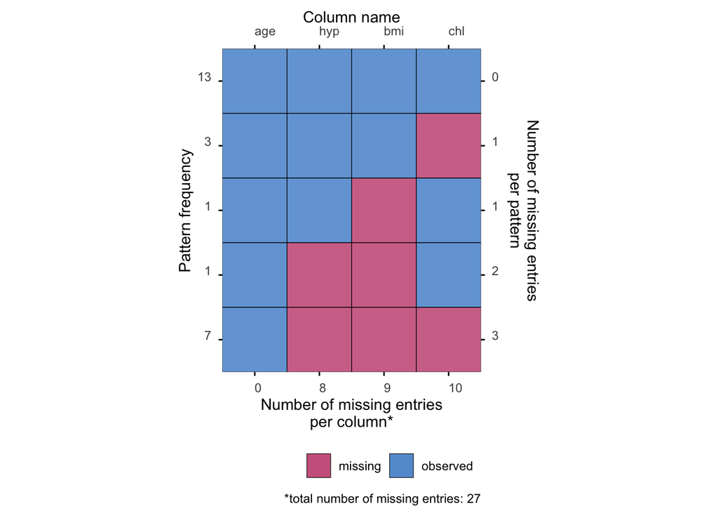

```r
plot_pattern(nhanes)
```

The missingness pattern shows that there are 27 missing values in total: 10 for `chl` , 9 for `bmi` and 8 for `hyp`. Moreover, there are thirteen completely observed rows, four rows with 1 missing, one row with 2 missings and seven rows with 3 missings. Looking at the missing data pattern is always useful (but may be difficult for datasets with many variables). It can give you an indication on how much information is missing and how the missingness is distributed.

##### Ad Hoc imputation methods

**5. Form a regression model where `age` is predicted from `bmi`.**

```r
fit <- with(nhanes, lm(age ~ bmi))
summary(fit)
```

```
Call:
lm(formula = age ~ bmi)

Residuals:
    Min      1Q  Median      3Q     Max
-1.2660 -0.5614 -0.1225  0.4660  1.2344

Coefficients:
            Estimate Std. Error t value Pr(>|t|)
(Intercept)  3.76718    1.31945   2.855   0.0127 *
bmi         -0.07359    0.04910  -1.499   0.1561
---
Signif. codes:  0 '***' 0.001 '**' 0.01 '*' 0.05 '.' 0.1 ' ' 1

Residual standard error: 0.8015 on 14 degrees of freedom
  (9 observations deleted due to missingness)
Multiple R-squared:  0.1383,    Adjusted R-squared:  0.07672
F-statistic: 2.246 on 1 and 14 DF,  p-value: 0.1561
```

By default, most statistical software will apply list-wise deletion as missing data method. These results therefore do not represent the *true* estimates, but the estimates on completely observed cases in the data.

**6. Impute the missing data in the `nhanes` dataset with mean imputation.**

```r
imp <- mice(nhanes, method = "mean", m = 1, maxit = 1)
```

The imputations are now done. As you can see, the algorithm ran for 1 iteration (`maxit = 1`) and presented us with only 1 imputation (`m = 1`) for each missing datum. This is correct, as substituting each missing data multiple times with the observed data mean would not make any sense (the inference would be equal, no matter which imputed dataset we would analyze). Likewise, more iterations would be computationally inefficient as the *observed* data mean does not change based on our imputations. We named the imputed object `imp` following the convention used in `mice`, but if you wish you can name it anything you’d like.

**7. Explore the imputed data with the `complete()` function. What do you think the variable means are? What happened to the regression equation after imputation?**

```r
complete(imp)
```

```
   age     bmi      hyp   chl
1    1 26.5625 1.235294 191.4
2    2 22.7000 1.000000 187.0
3    1 26.5625 1.000000 187.0
4    3 26.5625 1.235294 191.4
5    1 20.4000 1.000000 113.0
6    3 26.5625 1.235294 184.0
7    1 22.5000 1.000000 118.0
8    1 30.1000 1.000000 187.0
9    2 22.0000 1.000000 238.0
10   2 26.5625 1.235294 191.4
11   1 26.5625 1.235294 191.4
12   2 26.5625 1.235294 191.4
13   3 21.7000 1.000000 206.0
14   2 28.7000 2.000000 204.0
15   1 29.6000 1.000000 191.4
16   1 26.5625 1.235294 191.4
17   3 27.2000 2.000000 284.0
18   2 26.3000 2.000000 199.0
19   1 35.3000 1.000000 218.0
20   3 25.5000 2.000000 191.4
21   1 26.5625 1.235294 191.4
22   1 33.2000 1.000000 229.0
23   1 27.5000 1.000000 131.0
24   3 24.9000 1.000000 191.4
25   2 27.4000 1.000000 186.0
```

We see the repetitive numbers `26.5625` for `bmi`, `1.2352594` for `hyp`, and `191.4` for `chl`. These can be confirmed as the means of the respective variables (columns):

```r
colMeans(nhanes, na.rm = TRUE)
```

```
       age        bmi        hyp        chl
  1.760000  26.562500   1.235294 191.400000
```

We saw during the inspection of the missing data pattern that variable `age` has no missings. Therefore nothing is imputed for `age` because we would not want to alter the observed (and bonafide) values.

The imputed data can be inspected visually by comparing the distribution of the observed data to the distribution of the imputed data:

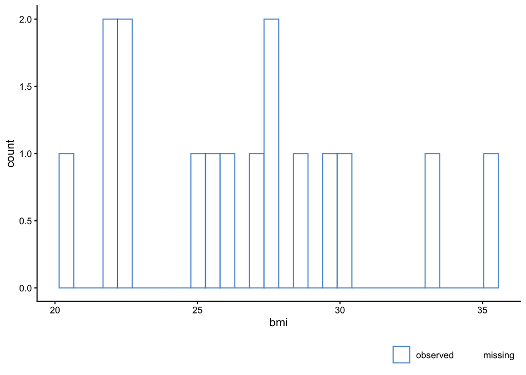

```r
ggmice(nhanes, aes(bmi)) +
        geom_histogram(fill = "white")
```

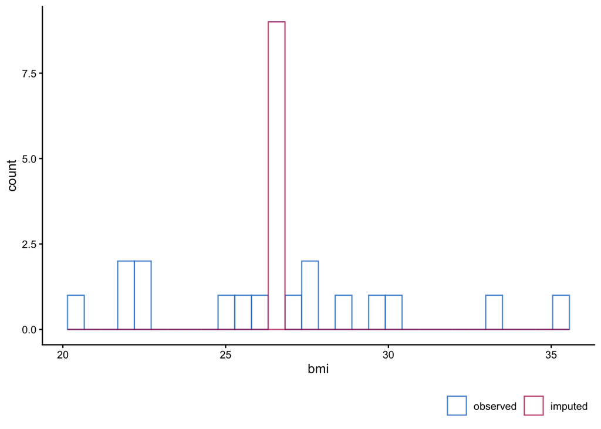

```r
ggmice(imp, aes(bmi)) +
        geom_histogram(fill = "white")
```

Every missing instance of `bmi` is filled in with the average observed `bmi` value.

What happened to the variability in the `bmi` variable compared after imputing the mean? Evaluate the standard deviation of the data before and after imputation:

```r
sd(nhanes$bmi, na.rm = TRUE)
```

```
[1] 4.215191
```

```r
sd(complete(imp)$bmi)
```

```
[1] 3.332401
```

This may affect the analysis after imputation. To inspect the regression model with the imputed data, run:

```r
fit <- with(imp, lm(age ~ bmi))
summary(fit)
```

```
# A tibble: 2 × 7
  term        estimate std.error statistic p.value  nobs df.residual
  <chr>          <dbl>     <dbl>     <dbl>   <dbl> <int>       <dbl>
1 (Intercept)   3.71      1.33        2.80  0.0103    25          23
2 bmi          -0.0736    0.0497     -1.48  0.152     25          23
```

It is clear that nothing changed, but then again this is not surprising as variable `bmi` is somewhat normally distributed and we are just adding weight to the mean.

**8. Impute the missing data in the `nhanes` dataset with regression imputation.**

```r
imp <- mice(nhanes, method = "norm.predict", m = 1, maxit = 1)
```

The imputations are now done. This code imputes the missing values in the data set by the regression imputation method. The argument `method = "norm.predict"` first fits a regression model for each observed value, based on the corresponding values in other variables and then imputes the missing values with the predicted values.

**9. Again, inspect the completed data and investigate the imputed data regression model.**

```r
complete(imp)
```

```
   age      bmi      hyp      chl
1    1 30.30418 1.060514 185.5990
2    2 22.70000 1.000000 187.0000
3    1 29.14212 1.000000 187.0000
4    3 21.23102 1.487796 215.7459
5    1 20.40000 1.000000 113.0000
6    3 20.20568 1.472942 184.0000
7    1 22.50000 1.000000 118.0000
8    1 30.10000 1.000000 187.0000
9    2 22.00000 1.000000 238.0000
10   2 25.93849 1.276630 201.9402
11   1 31.33739 1.131401 192.9120
12   2 20.05984 1.191469 158.3309
13   3 21.70000 1.000000 206.0000
14   2 28.70000 2.000000 204.0000
15   1 29.60000 1.000000 180.6916
16   1 32.49945 1.148235 201.5325
17   3 27.20000 2.000000 284.0000
18   2 26.30000 2.000000 199.0000
19   1 35.30000 1.000000 218.0000
20   3 25.50000 2.000000 244.5824
21   1 35.77269 1.139734 226.1658
22   1 33.20000 1.000000 229.0000
23   1 27.50000 1.000000 131.0000
24   3 24.90000 1.000000 246.3647
25   2 27.40000 1.000000 186.0000
```

The repetitive numbering is gone. We have now obtained a more natural looking set of imputations: instead of filling in the same `bmi` for all ages, we now take `age` (as well as `hyp` and `chl`) into account when imputing `bmi`.

The imputed data can be inspected visually with:

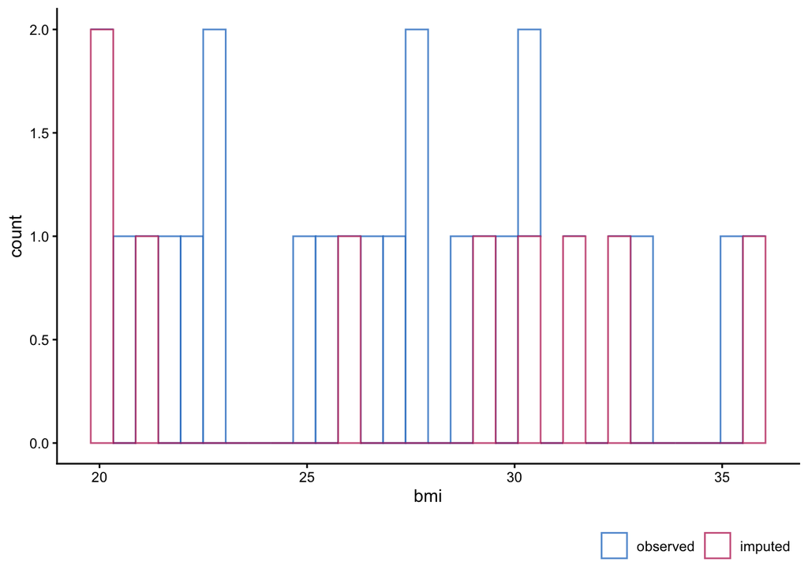

```r
ggmice(imp, aes(bmi)) +
  geom_histogram(fill = "white")
```

What happened to the correlation between `bmi` and `age`? Evaluate the correlation before and after imputation:

```r
cor(nhanes[c("bmi", "age")], use = "pairwise.complete")
```

```
           bmi        age
bmi  1.0000000 -0.3718535
age -0.3718535  1.0000000
```

```r
cor(complete(imp)[c("bmi", "age")])
```

```
           bmi        age
bmi  1.0000000 -0.5900226
age -0.5900226  1.0000000
```

This may affect the analysis after imputation. To inspect the regression model with the imputed data, run:

```r
fit <- with(imp, lm(age ~ bmi))
summary(fit)
```

```
# A tibble: 2 × 7
  term        estimate std.error statistic    p.value  nobs df.residual
  <chr>          <dbl>     <dbl>     <dbl>      <dbl> <int>       <dbl>
1 (Intercept)    4.54     0.804       5.64 0.00000962    25          23
2 bmi           -0.103    0.0295     -3.50 0.00191       25          23
```

It is clear that something has changed. In fact, we extrapolated (part of) the regression model for the observed data to missing data in `bmi`. In other words; the relation (read: information) gets stronger and we’ve obtained more observations.

**Conclusion**

We have seen that imputation is straightforward with `mice`. However, don’t let the simplicity of the software fool you into thinking that the problem itself is also straightforward. In the next tutorial we will therefore explore how the mice package can flexibly provide us the tools to assess and control the imputation of missing data.

**References**

Rubin, D. B. *Multiple imputation for nonresponse in surveys*. John Wiley & Sons, 1987.

Schafer, J.L. (1997). *Analysis of Incomplete Multivariate Data*. London: Chapman & Hall.

Van Buuren, S. and Groothuis-Oudshoorn, K. (2011). mice: Multivariate Imputation by Chained Equations in R. *Journal of Statistical Software*, 45(3), 1-67. [pdf](http://www.jstatsoft.org/v45/i03/paper)